# 06_22_2020

### Introduction

I've re-organized things a bit. We are now about 3 months into the pandemic in all of the counties. While a comparison of cumulative number of cases is still interesting, I've moved those graphs to the end in order to stress what is going on in the occurrence of new cases (now up front.) Also, because of the rather large differential in the size of the population, I've normalized most of the statistics so they can be (more or less) directly compared.

```
          06/22/2020
```

### Summary for selected counties

| Statistic | Campbell, KY | Fulton, GA | Hamilton, OH | Hartford, CT | Leon, FL | Suffolk, NY |
| --- | --- | --- | --- | --- | --- | --- |
| Population | 93,584 | 1,063,937 | 817,473 | 891,720 | 293,582 | 1,476,601 |
| Cases | 227 | 5,496 | 3,829 | 11,405 | 573 | 40,972 |
| Deaths | 12 | 304 | 186 | 1,350 | 8 | 1,964 |
| Cases per 100,000 | 242 | 516 | 468 | 1,278 | 195 | 2,774 |
| Deaths per 100,000 | 12 | 28 | 22 | 151 | 2 | 133 |
| Date of first case | 3/24/20 | 3/3/20 | 3/19/20 | 3/14/20 | 3/19/20 | 3/8/20 |
| Number of Days | 90 | 111 | 95 | 100 | 95 | 106 |
| Maximum Number of Cases | 18 | 214 | 134 | 472 | 49 | 1,795 |

The lowest reported confirmed cases per 100,000 population is Leon County followed (in increasing order) by Campbell County, Hamilton County, Fulton County, Hartford County, and Suffolk county.

The only difference in the ordering of the death rates is that the death rate in Hartford county is higher than that in Suffolk county.

As I noted earlier, it appears that at least part of low death rate in Leon County is due to a Florida requirement in the definition of a confirmed case death.

## The last 7 days

The following table displays the number of new cases for the lastest 7 days of available data in each of the counties. The negative number is apparently a correction of previously reported data.

| Date | Campbell | Fulton | Hamilton | Hartford | Leon | Suffolk |
| --- | --- | --- | --- | --- | --- | --- |
| 6/15/20 | 0 | 51 | 65 | 13 | 5 | 33 |
| 6/16/20 | 0 | -9 | 66 | 30 | 9 | 46 |
| 6/17/20 | 5 | 144 | 58 | 23 | 2 | 32 |
| 6/18/20 | 1 | 33 | 134 | 38 | 10 | 40 |
| 6/19/20 | 6 | 75 | 126 | 36 | 13 | 54 |
| 6/20/20 | 6 | 44 | 110 | 34 | 49 | 44 |
| 6/21/20 | 2 | 52 | 85 | 13 | 16 | 64 |

## Examine new cases, moving averages

The moving averages have now been normalized as the number of cases per 100,000 population. As noted before, the averages are 'trailing' in that the point on the graph represents the average number of new confirmed cases for that day and the $k-1$ previous days ($k = 5,7,10$).

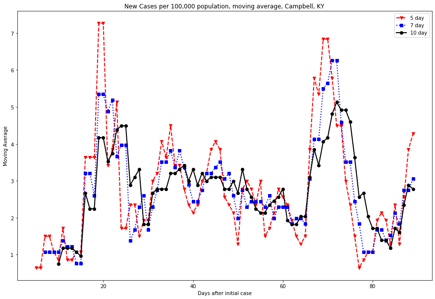

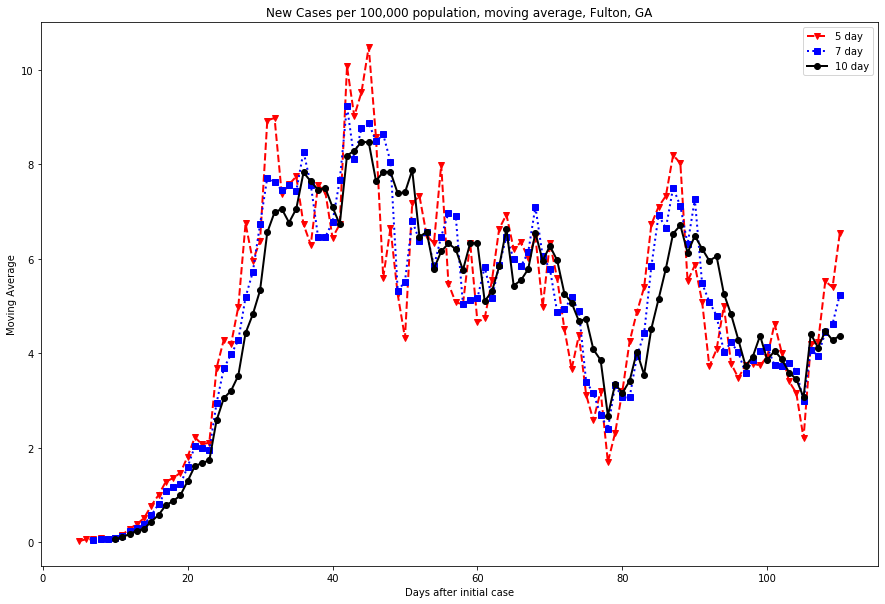

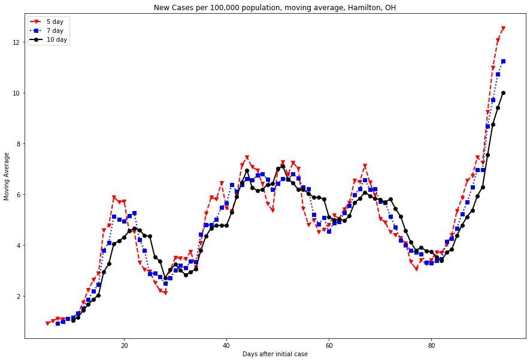

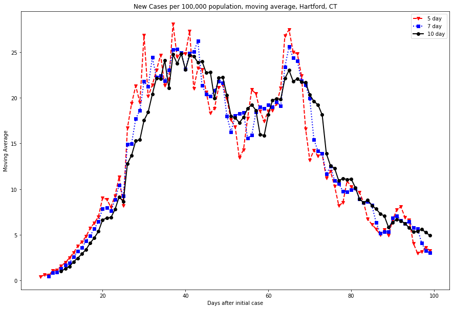

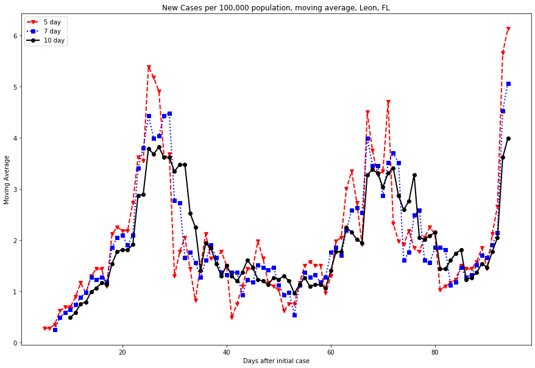

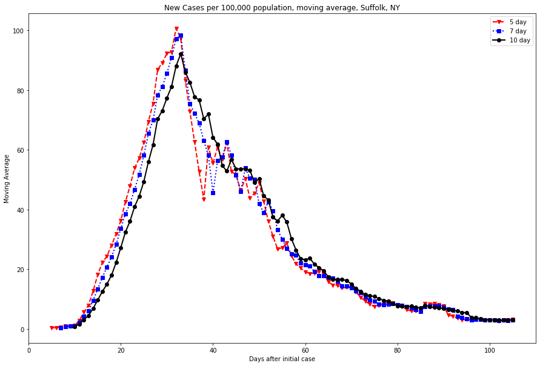

*Examining estimated doubling time*  
Although the overall curves can't be classified by a single exponential model. A piecewise examination allows us to estimate doubling time, how long at the present rate will it take to have twice the number of cases. If we select k consecutive days and assume that within that time frame that $\log(y)=\beta_0 + \beta_1 * t$. Then the time it takes to double the number of cases is $\frac{\log_{10}(2)}{\beta_1}$.  
I used three analyses of doubling time estimated using 5 , 7, and 10 days.

In each case I started with day 0 and took the $k$ days including it and estimated $\beta$ ($k = 5, 7, 10$). I then took the next $k$ days starting with day $k$ and so on until there were less that $k$ days left. For each of these time frames, I estimate $\beta$ assuming exponential growth and plotted the resulting estimates of doubling time in the graphs.

This examination has the advantage of putting the estimated growth on a somewhat intuitive scale. The larger the doubling time the slower the rate of increase.

Today, I dropped Suffolk county from the graph because it requires a larger scale to accomodate and, I think, it doesn't allow comparisons of the others.

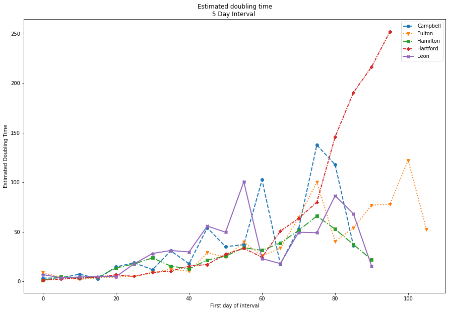

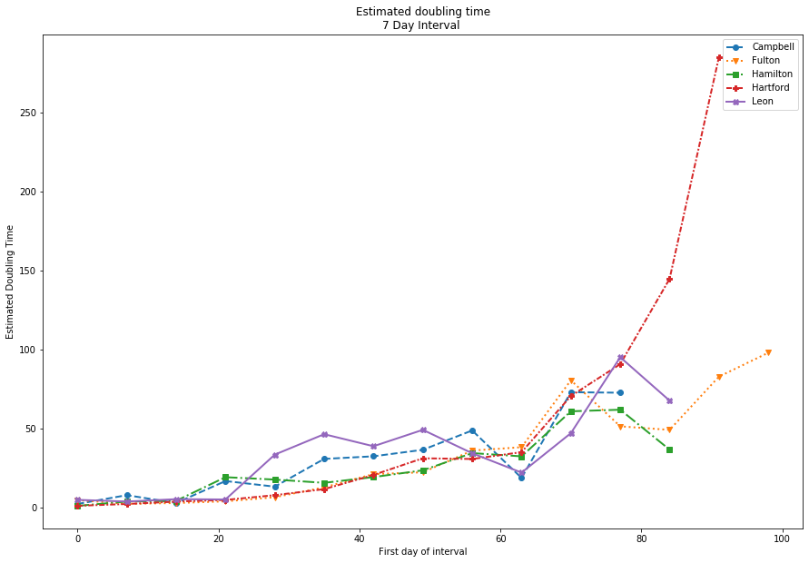

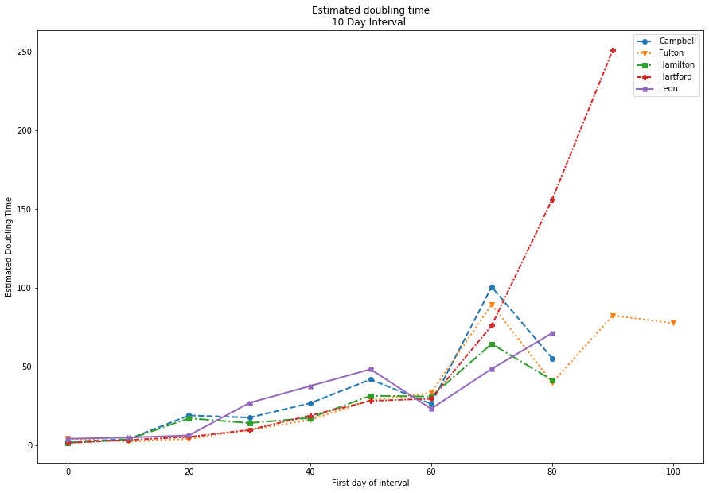

### Confidence Intervals for doubling time.

To get a feel for the variability of the estimates, we can calculate confidence intervals for the estimated doubling times by first calculating the confidence interval for the slope and then tranforming the endpoints for the confidence interval for the estimated slope to endpoints for the doubling time. An example is provided in the following table. It gives a 95% confidence interval for the doubling time using the 60$^{th}$ day as the starting interval and using the following 9 days to estimate the slope.

| County | Doubling (days) | Lower 95 % C.I. | Upper 95 % C.I. |
| --- | --- | --- | --- |
| Campbell, KY | 26.3 | 20.4 | 37.0 |
| Fulton, GA | 33.3 | 29.9 | 37.6 |
| Hamilton, OH | 31.0 | 28.9 | 33.5 |
| Hartford, CT | 29.7 | 25.8 | 34.9 |
| Leon, FL | 23.2 | 19.3 | 29.3 |
| Suffolk, NY | 116.4 | 109.9 | 123.8 |

## Cumulative Number of cases by county.

I split this into three graphs, since the scale of the original version of the graph was determined by Suffolk and Hartford County.

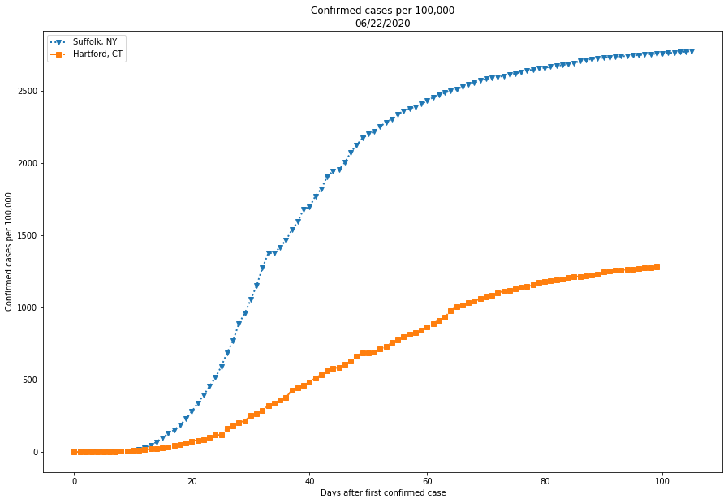

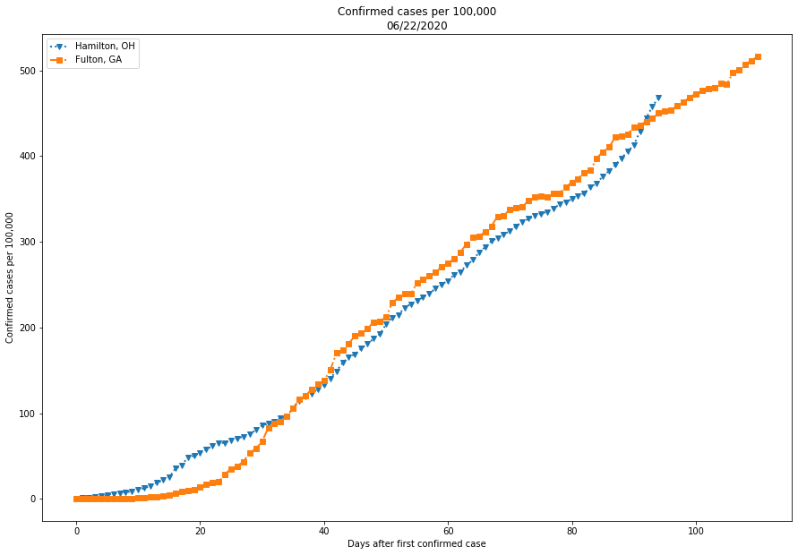

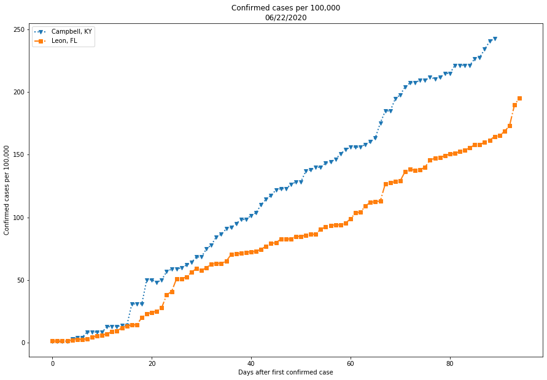

*Log rate of occurrence*  
I left all counties on the same graph for now since the log scale compensates a bit for the rather large differences. Recall that if the occurrence was exponential, the semi-log graph would be linear. This doesn't occur in any of the counties. As the above graph demonstrated, after about 30 days, Hamilton and Fulton counties are extremely similar. Suffolk county has, at least almost, reached a plateau (meaning very few new cases).

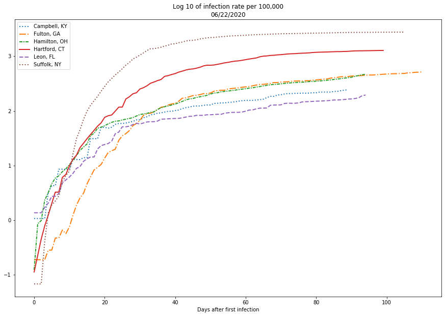